# Data Science Capstone Milestone Report

Meltem YILMAZ

2/18/2021

## Overview

This is an exploratory data analysis report of a project being developed. The main objective of the project is to develop a shiny web application that will predict the suggested words based on certain words supplied by the users.This document explains the certain aspects of the data available.

## Loading Libraries

```r
library(quanteda)
library(readr)
library(readtext)
library(stringi)
library(ggsci)
library(stringr)
library(ggplot2)
library(dplyr)
library(ngram)
```

## Loading the data

We have three English texts: a file with blogs, a file with news and a file with Tweets.

```r
data <- readtext("texts/*.txt",
                   docvarsfrom = "filenames",
                   docvarnames = c("lang", "type"),
                   dvsep = "-",
                   encoding = "utf-8")
head(data)
```

```
## readtext object consisting of 3 documents and 2 docvars.
## # Description: df[,4] [3 × 4]
##   doc_id            text                lang  type
## * <chr>             <chr>               <chr> <chr>
## 1 en_US-blogs.txt   "\"In the yea\"..." en_US blogs
## 2 en_US-news.txt    "\"He wasn't \"..." en_US news
## 3 en_US-twitter.txt "\"How are yo\"..." en_US twitter
```

## Corpus Development

For each document, 3000 sentences are sampled without replacement using the `corpus_sample()` function from the quanteda package. This corpus is used to make a document feature matrix (DFM) that we can use for the word frequency analyses.

```r
corp <- corpus(data)
corpsentc <- corpus_reshape(corp, to=c("sentences"), use_docvars = TRUE)
corps <- corpus_sample(corpsentc, size = 3000, replace = FALSE, by = "document")
corps2 <- corpus_reshape(corps, to = "documents")

dtm <- dfm(corps2, tolower=TRUE, stem=FALSE, remove=stopwords('en'), remove_punct=TRUE,
           remove_numbers = TRUE, remove_symbols = TRUE)
dtm <- dfm_trim(dtm, min_termfreq = 10)
```

## Word frequencies

These are the word frequencies without the stopwords.

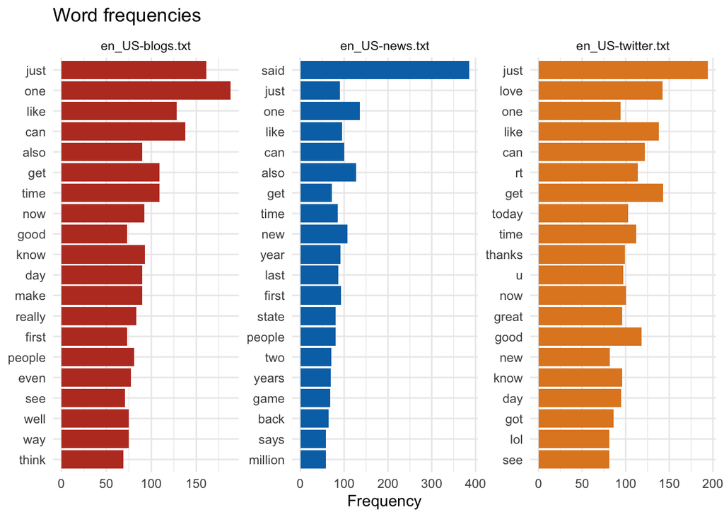

```r
textstat_frequency(dtm, n = 20, groups = "docid_") %>%
    ggplot() +
        facet_wrap(~group, scales = "free") +
        geom_bar(aes(x = reorder(feature, frequency), y = frequency, fill=group), stat="identity") +
        scale_fill_nejm(guide=FALSE)+
        coord_flip() +
        labs(x = NULL, y = "Frequency") +
        theme_minimal() +
        ggtitle("Word frequencies")
```

## Keyness Twitter vs News

This is a way to compare text sources and to assess which words have differential expression (frequencies) across the sources. In this plot, I compared the Twitter and news texts. Especially the word “said” is more often used in news articles compared to Twitter. Words like “thanks”, “rt” (meaning retweet), “follow” and “lol” are more often used on Twitter.

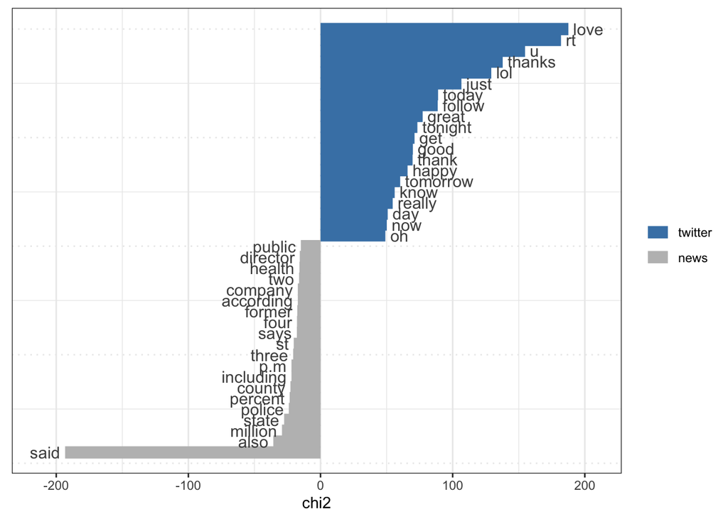

```r
type_corp <- corpus_subset(corps2,
                             type %in% c("twitter", "news"))
typedfm <- dfm(type_corp, groups = "type", tolower=TRUE, stem=FALSE, remove=stopwords('en'), remove_punct=TRUE,
               remove_numbers = TRUE, remove_symbols = TRUE)
result_keyness <- textstat_keyness(typedfm, target = "twitter")
textplot_keyness(result_keyness, color=c("steelblue", "grey"))
```

## N-gram Tokenization

Tokenizing means splitting the data in smaller units, in this case words. The format is N-grams stored in Term Document Matrices or Document Term Matrix. we use a Document Term Matrix (DTM) representation: documents as the rows, terms/words as the columns, frequency of the term in the document as the entries. Because the number of unique words in the corpus the dimension can be large. Ngram models are created to explore word frequences. We can use RWeka package to create unigrams, bigrams, and trigrams.

```r
toks <- tokens(corps2, remove_punct=TRUE, remove_numbers = TRUE, remove_symbols = TRUE)
ntoken(toks)
```

```
##   en_US-blogs.txt    en_US-news.txt en_US-twitter.txt
##             53735             54352             34616
```

## Bigram Analysis

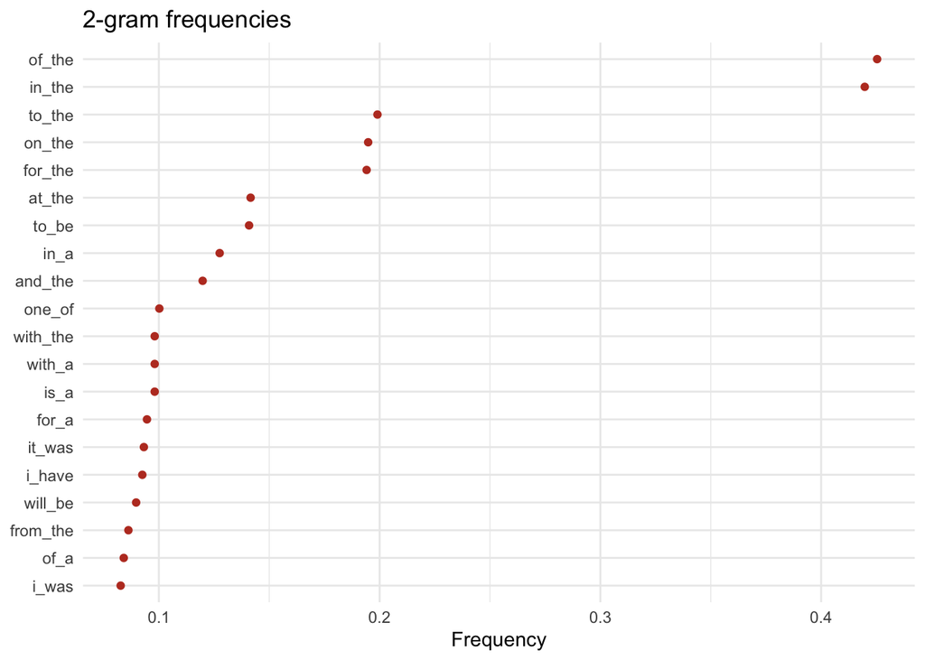

```r
toks_ngram <- tokens_ngrams(toks, n = 2)
dfngram <- dfm(toks_ngram)
tstat_freq <- textstat_frequency(dfngram)

tstat_freq %>%
    mutate(rel_freq = frequency/sum(frequency)*100) %>%
    arrange(rel_freq) %>%
    top_n(20) %>%
    ggplot(aes(x = reorder(feature, rel_freq), y = rel_freq)) +
    geom_point(color=pal_nejm()(1)) +
    coord_flip() +
    labs(x = NULL, y = "Frequency") +
    theme_minimal() +
    ggtitle("2-gram frequencies")
```

## Trigram Analysis

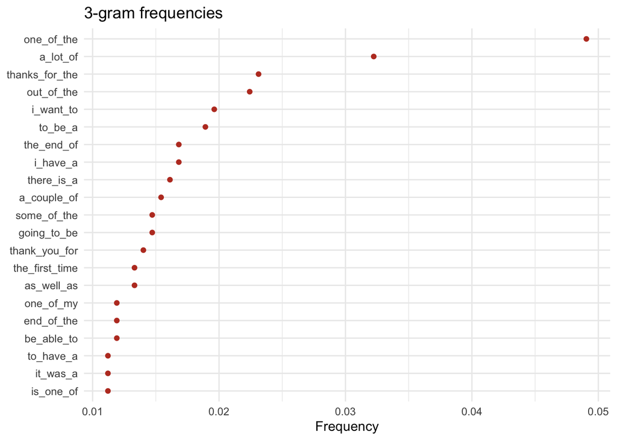

```r
toks_ngram <- tokens_ngrams(toks, n = 3)
dfngram <- dfm(toks_ngram)
tstat_freq <- textstat_frequency(dfngram)

tstat_freq %>%
    mutate(rel_freq = frequency/sum(frequency)*100) %>%
    arrange(rel_freq) %>%
    top_n(20) %>%
    ggplot(aes(x = reorder(feature, rel_freq), y = rel_freq)) +
    geom_point(color=pal_nejm()(1)) +
    coord_flip() +
    labs(x = NULL, y = "Frequency") +
    theme_minimal() +
    ggtitle("3-gram frequencies")
```

## Quadgram Analysis

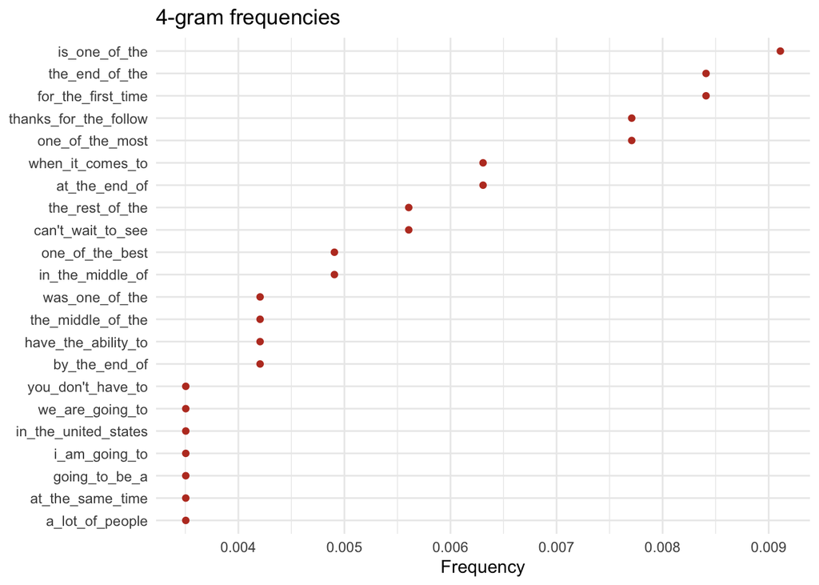

```r
toks_ngram <- tokens_ngrams(toks, n = 4)
dfngram <- dfm(toks_ngram)
tstat_freq <- textstat_frequency(dfngram)

tstat_freq %>%
    mutate(rel_freq = frequency/sum(frequency)*100) %>%
    arrange(rel_freq) %>%
    top_n(20) %>%
    ggplot(aes(x = reorder(feature, rel_freq), y = rel_freq)) +
    geom_point(color=pal_nejm()(1)) +
    coord_flip() +
    labs(x = NULL, y = "Frequency") +
    theme_minimal() +
    ggtitle("4-gram frequencies")
```

## Strategy and Plan for the prediction model

This is just an exploratory data analysis in order to understand data:

- Different set of words
- The association between words
  - Bigram
  - Trigram
  - Quadgram
- Frequencies of the word(s)

While the development is still in process, the following will be considered:

- May exclude stop words to reduce the memory usage and run time
- May also stem the words to further reduce memory usage and run time
- Will use the profanity terms available online to remove them
- Will train the model to predict the suggested words:
  - Create an algorithm that uses the given word(s)
  - Uses quadgram, trigram or bigram in the same order
  - Displays the next word to be selected
- Minimize the memory usage and run time
- Develop a Shiny application to upload it on the Shiny website